[output not shown]

# 1 Background

As a statistical consultant working for a real estate investment firm, your task is to develop a model to predict the selling price of a given home in Ames, Iowa. Your employer hopes to use this information to help assess whether the asking price of a house is higher or lower than the true value of the house. If the home is undervalued, it may be a good investment for the firm.

# 2 Training Data and relevant packages

In order to better assess the quality of the model you will produce, the data have been randomly divided into three separate pieces: a training data set, a testing data set, and a validation data set. For now we will load the training data set, the others will be loaded and used later.

```r
load("ames_train.Rdata")
```

Use the code block below to load any necessary packages

```r
library(statsr)
library(dplyr)
library(BAS)
library(tidyverse)
library(viridis)
library(hrbrthemes)
library(MASS)
library(BAS)
options(scipen = 999)
memory.limit(size = 300000)
```

```
## [1] 300000
```

## 2.1 Part 1 - Exploratory Data Analysis (EDA)

When you first get your data, it’s very tempting to immediately begin fitting models and assessing how they perform. However, before you begin modeling, it’s absolutely essential to explore the structure of the data and the relationships between the variables in the data set.

Do a detailed EDA of the ames_train data set, to learn about the structure of the data and the relationships between the variables in the data set (refer to Introduction to Probability and Data, Week 2, for a reminder about EDA if needed). Your EDA should involve creating and reviewing many plots/graphs and considering the patterns and relationships you see.

After you have explored completely, submit the three graphs/plots that you found most informative during your EDA process, and briefly explain what you learned from each (why you found each informative).

First, we begin by looking at the distribution of house prices within the data set. Since the price is the variable we ultimately want to predict, it is the most important variable within the data set. By evaluating its distribution, we can get an idea of its distribution, any outliers, whether it is unimodal, and many other insights. Here, we see that price is right-skewed and unimodal, with a concentration around $140,000 and some possible outliers above $500,000. Comparing the mean and median of the data set emphasizes the skewness of the data set; the mean price being greater than the median price is further evidence that the distribution of price is right-skewed. Lastly, the range of price appears to be between about $10,000 to about $625,000.

Next, since the distribution of price (as seen in the above graph) is skewed, it would be beneficial to take the natural log of price and utilize that variable in further analysis. Here, we want to see the impact the quality of a house has on its ultimate price. Therefore, we can use a boxplot to gauge the center and spread of `logprice` for each level of quality. From the boxplot, it is obvious that the price of a house increases with each level of quality, as seen by the center of each distribution. The quality levels in the middle (4-7) have larger ranges than higher and lower quality houses. In general, we can see that low quality houses will have low prices and higher quality houses will have higher prices. For the middle quality levels, the median house for that level is higher than the immediately lower quality (the median price for a house with quality 7 is higher than the median price for a house with quality 6, and so on); however, there is a greater spread, so there are certainly individual houses with a higher quality that are a lower price than another lower quality house.

Lastly, we want to evaluate the impact the area and features of a house has on its price. For this analysis, we will consider a “Feature” to be if the house has a garage, a basement, both, or neither. In evaluating the mean(`logarea`) vs. mean(`logprice`) of the data set for each level of features, we can see that a house that has neither a garage nor a basement is generally smaller and has a lower price than the other houses. Further, a house that has both a garage and a basement is generally larger and has a higher price than the other houses. However, we can also see that the effect of having a garage and basement is larger for the price of the house than the size. Houses that have a garage only and basement only are around the same price; however, the houses with only a garage tend to be a bit larger on average than those with only a basement.

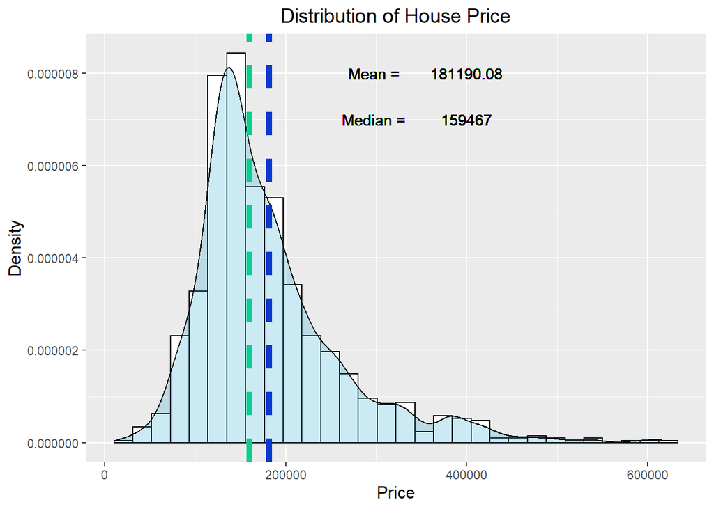

```r
ames_train_log <- ames_train %>%
  mutate(logprice = log(price), logarea = log(area))
ames_train_log %>%
  ggplot(aes(x=price)) + geom_histogram(aes(y = ..density..), color = "black", fill = "white", bins = 30) +
  geom_density(alpha = 0.2, fill = "#0094c2") +
  geom_vline(aes(xintercept = mean(price)), col = '#0a39cf', size = 2, linetype = 'dashed') +
  geom_vline(aes(xintercept = median(price)), col = '#0acf91', size = 2, linetype = 'dashed') +
  geom_text(x=300000, y = 0.000008, label = 'Mean = ') +
  geom_text(x=400000, y = 0.000008, label = round(mean(ames_train_log$price), 2)) + geom_text(x=300000, y = 0.000007, label = 'Median = ') +
  geom_text(x=400000, y = 0.000007, label = round(median(ames_train_log$price), 2)) +
 theme(plot.title = element_text(size = 14, hjust = 0.5), axis.title.x = element_text(size = 12, hjust = 0.5), axis.title.y = element_text(size = 12, hjust = 0.5)) +
  labs(x = 'Price', y = 'Density', title = 'Distribution of House Price')
```

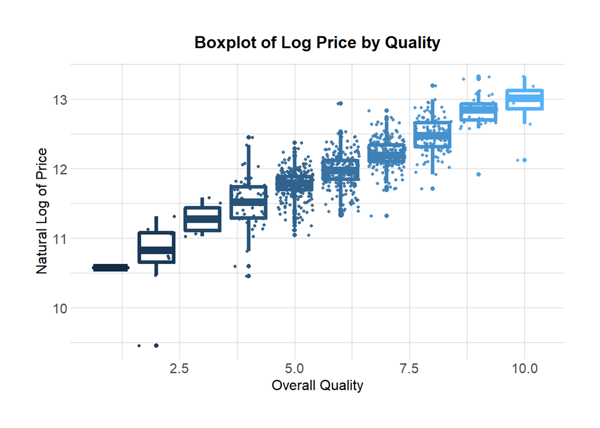

```r
ames_train_log %>%
  ggplot(aes(x=Overall.Qual, y = logprice, group = Overall.Qual, color = Overall.Qual)) +
  geom_boxplot(lwd = 1.5) +
  scale_fill_viridis(discrete = TRUE, alpha = 0.6) +
  geom_jitter(size  = 0.9, alpha = 0.9) +
  theme_ipsum() +
  theme(legend.position = 'none', plot.title = element_text(size = 14, hjust = 0.5), axis.title.x =
          element_text(size = 12, hjust = 0.5), axis.title.y = element_text(size = 12, hjust = 0.5)) +
  ggtitle("Boxplot of Log Price by Quality") + labs(x = "Overall Quality", y = "Natural Log of Price")
```

```r
ames_train_log_summary <- ames_train_log %>%
  mutate(Features = ifelse(((is.na(Total.Bsmt.SF) | Total.Bsmt.SF == 0) & (is.na(Garage.Area) | Garage.Area ==0)), 'None', ifelse(((is.na(Total.Bsmt.SF) | Total.Bsmt.SF == 0) & !(is.na(Garage.Area) | Garage.Area == 0)), "Garage Only", ifelse(((is.na(Garage.Area) | Garage.Area == 0) & !(is.na(Total.Bsmt.SF) | Total.Bsmt.SF == 0)), "Basement Only", "Garage + Basement")))) %>%
  group_by(Features) %>%
  summarise(Mean_LogArea = mean(logarea), Mean_LogPrice = mean(logprice))
```

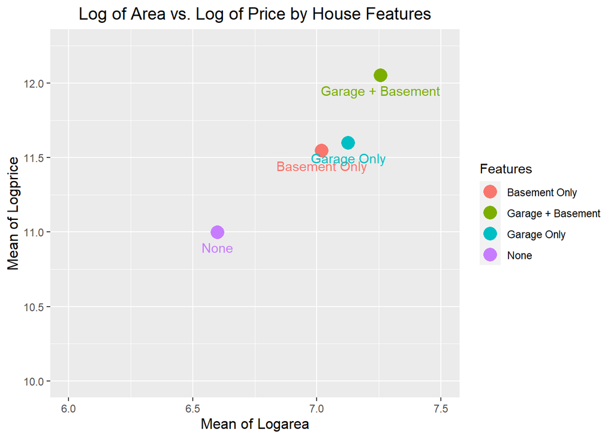

```r
ames_train_log_summary %>%
  ggplot(aes(x=Mean_LogArea, y = Mean_LogPrice, color = Features)) + geom_point(size = 5) +
  xlim(6, 7.5) + ylim(10, 12.25) +
  geom_text(aes(x=Mean_LogArea, y = Mean_LogPrice, label = Features), data = ames_train_log_summary, vjust = 2) +
   theme(plot.title = element_text(size = 14, hjust = 0.5), axis.title.x = element_text(size = 12, hjust = 0.5), axis.title.y = element_text(size = 12, hjust = 0.5)) +
  labs(x = 'Mean of Logarea', y = 'Mean of Logprice', title = 'Log of Area vs. Log of Price by House Features')
```

* * *

## 2.2 Part 2 - Development and assessment of an initial model, following a semi-guided process of analysis

### 2.2.1 Section 2.1 An Initial Model

In building a model, it is often useful to start by creating a simple, intuitive initial model based on the results of the exploratory data analysis. (Note: The goal at this stage is **not** to identify the “best” possible model but rather to choose a reasonable and understandable starting point. Later you will expand and revise this model to create your final model.

Based on your EDA, select *at most* 10 predictor variables from “ames_train” and create a linear model for `price` (or a transformed version of price) using those variables. Provide the *R code* and the *summary output table* for your model, a *brief justification* for the variables you have chosen, and a *brief discussion* of the model results in context (focused on the variables that appear to be important predictors and how they relate to sales price).

For my initial model, given the variables I explored in the first step, I included the natural log of `price` as the response variable. I included `logprice` instead of `price` because of the skewness I noted in the first step. Then, I included all of the response variables I explored in the first step, as well as related variables. For example, I created the `Features` variable to explore whether having a basement, garage, or both would be a relevant predictor of `price`. It is still possible that the size of a basement and/or garage is more relevant than the mere existence of one, so I included the relevant size variables to ascertain if those would be better predictors than `Features`.

```r
ames_train_init <- ames_train_log %>%
  mutate(Features = ifelse(((is.na(Total.Bsmt.SF) | Total.Bsmt.SF == 0) & (is.na(Garage.Area) | Garage.Area ==0)), 'None', ifelse(((is.na(Total.Bsmt.SF) | Total.Bsmt.SF == 0) & !(is.na(Garage.Area) | Garage.Area == 0)), "Garage Only", ifelse(((is.na(Garage.Area) | Garage.Area == 0) & !(is.na(Total.Bsmt.SF) | Total.Bsmt.SF == 0)), "Basement Only", "Garage + Basement")))) %>%
  dplyr::select(logprice, Features, logarea, Overall.Qual, Overall.Cond, Total.Bsmt.SF, Garage.Area, Garage.Cars)
lm_ames_train_init <- lm(logprice ~ ., ames_train_init)

summary(lm_ames_train_init)
```

```
##
## Call:
## lm(formula = logprice ~ ., data = ames_train_init)
##
## Residuals:
##      Min       1Q   Median       3Q      Max
## -1.64563 -0.08206  0.01676  0.10043  0.54539
##
## Coefficients:
##                             Estimate Std. Error t value             Pr(>|t|)
## (Intercept)               8.06894744 0.15229927  52.981 < 0.0000000000000002
## FeaturesGarage + Basement 0.01880322 0.03260392   0.577               0.5643
## FeaturesGarage Only       0.11136300 0.05641587   1.974               0.0487
## FeaturesNone              0.18696109 0.09389838   1.991               0.0467
## logarea                   0.33815545 0.02245198  15.061 < 0.0000000000000002
## Overall.Qual              0.12784330 0.00584344  21.878 < 0.0000000000000002
## Overall.Cond              0.04873438 0.00538754   9.046 < 0.0000000000000002
## Total.Bsmt.SF             0.00023947 0.00001817  13.182 < 0.0000000000000002
## Garage.Area               0.00010109 0.00005924   1.706               0.0883
## Garage.Cars               0.07307724 0.01811242   4.035            0.0000589
##
## (Intercept)               ***
## FeaturesGarage + Basement
## FeaturesGarage Only       *
## FeaturesNone              *
## logarea                   ***
## Overall.Qual              ***
## Overall.Cond              ***
## Total.Bsmt.SF             ***
## Garage.Area               .
## Garage.Cars               ***
## ---
## Signif. codes:  0 '***' 0.001 '**' 0.01 '*' 0.05 '.' 0.1 ' ' 1
##
## Residual standard error: 0.1745 on 988 degrees of freedom
##   (2 observations deleted due to missingness)
## Multiple R-squared:  0.8292, Adjusted R-squared:  0.8276
## F-statistic: 532.9 on 9 and 988 DF,  p-value: < 0.00000000000000022
```

### 2.2.2 Section 2.2 Model Selection

Now either using `BAS` another stepwise selection procedure choose the “best” model you can, using your initial model as your starting point. Try at least two different model selection methods and compare their results. Do they both arrive at the same model or do they disagree? What do you think this means?

Next, we evaluated the adjusted R^2 for the full model, then the model eliminating each variable individually. If a model with an eliminated variable has a higher adjusted R^2 than the original, we will continue to eliminate variables until the adjusted R^2 is maximized. As with BIC, the adjusted R^2 considers the number of parameters in the model. Here, we find that the original model maximizes adjusted R^2 also.

Lastly, we explored Bayesian Model Averaging to find the posterior probability of each model using a prior distribution and likelihood. In this way, we found that the model with the highest posterior probability (0.5413) is the one that includes `Garage.Cars`, `Total.Bsmt.SF`, `Overall.Cond`, `Overall.Qual`, and `logarea`; excluding `Features`, and `Garage.Area`. Interestingly, using the BMA method provides a different conclusion than the previous model selection methods.

```r
#Utilizing backwards elimination given AIC and BIC criteria to find the model that minimizes AIC and BIC
AIC_init <- stepAIC(lm_ames_train_init, k = 2)
```

```
## Start:  AIC=-3474.48
## logprice ~ Features + logarea + Overall.Qual + Overall.Cond +
##     Total.Bsmt.SF + Garage.Area + Garage.Cars
##
##                 Df Sum of Sq    RSS     AIC
## <none>                       30.092 -3474.5
## - Garage.Area    1    0.0887 30.181 -3473.5
## - Features       3    0.2271 30.319 -3473.0
## - Garage.Cars    1    0.4958 30.588 -3460.2
## - Overall.Cond   1    2.4922 32.584 -3397.1
## - Total.Bsmt.SF  1    5.2927 35.385 -3314.8
## - logarea        1    6.9091 37.001 -3270.2
## - Overall.Qual   1   14.5786 44.671 -3082.2
```

```r
BIC_init <- stepAIC(lm_ames_train_init, k = log(7), trace = TRUE)
```

```
## Start:  AIC=-3475.02
## logprice ~ Features + logarea + Overall.Qual + Overall.Cond +
##     Total.Bsmt.SF + Garage.Area + Garage.Cars
##
##                 Df Sum of Sq    RSS     AIC
## <none>                       30.092 -3475.0
## - Garage.Area    1    0.0887 30.181 -3474.0
## - Features       3    0.2271 30.319 -3473.4
## - Garage.Cars    1    0.4958 30.588 -3460.7
## - Overall.Cond   1    2.4922 32.584 -3397.6
## - Total.Bsmt.SF  1    5.2927 35.385 -3315.3
## - logarea        1    6.9091 37.001 -3270.7
## - Overall.Qual   1   14.5786 44.671 -3082.7
```

```r
AIC_init
```

```
##
## Call:
## lm(formula = logprice ~ Features + logarea + Overall.Qual + Overall.Cond +
##     Total.Bsmt.SF + Garage.Area + Garage.Cars, data = ames_train_init)
##
## Coefficients:
##               (Intercept)  FeaturesGarage + Basement
##                 8.0689474                  0.0188032
##       FeaturesGarage Only               FeaturesNone
##                 0.1113630                  0.1869611
##                   logarea               Overall.Qual
##                 0.3381554                  0.1278433
##              Overall.Cond              Total.Bsmt.SF
##                 0.0487344                  0.0002395
##               Garage.Area                Garage.Cars
##                 0.0001011                  0.0730772
```

```r
BIC_init
```

```
##
## Call:
## lm(formula = logprice ~ Features + logarea + Overall.Qual + Overall.Cond +
##     Total.Bsmt.SF + Garage.Area + Garage.Cars, data = ames_train_init)
##
## Coefficients:
##               (Intercept)  FeaturesGarage + Basement
##                 8.0689474                  0.0188032
##       FeaturesGarage Only               FeaturesNone
##                 0.1113630                  0.1869611
##                   logarea               Overall.Qual
##                 0.3381554                  0.1278433
##              Overall.Cond              Total.Bsmt.SF
##                 0.0487344                  0.0002395
##               Garage.Area                Garage.Cars
##                 0.0001011                  0.0730772
```

```r
#Evaluating Adjusted R^2 of models eliminating a variable versus the original model.  If a given model that eliminates a variable has a greater Adjusted R^2, then we will continue to eliminate variables from that model until the Adjusted R^2 is maximized.

AdjRsq <- function(x, y) {
  z <- x %>%
  dplyr::select(-{{y}})

  lm <- lm(logprice ~ ., data = z)
  adjrsq <- summary(lm)$adj.r.squared
  return(adjrsq)
}

summary(lm(logprice ~., data = ames_train_init))$adj.r.squared
```

```
## [1] 0.8276289
```

```r
AdjRsq(ames_train_init, Garage.Area)
```

```
## [1] 0.8272958
```

```r
AdjRsq(ames_train_init, Features)
```

```
## [1] 0.8268538
```

```r
AdjRsq(ames_train_init, Garage.Cars)
```

```
## [1] 0.8249661
```

```r
AdjRsq(ames_train_init, Overall.Cond)
```

```
## [1] 0.8135419
```

```r
AdjRsq(ames_train_init, Total.Bsmt.SF)
```

```
## [1] 0.7981071
```

```r
AdjRsq(ames_train_init, logarea)
```

```
## [1] 0.7882673
```

```r
AdjRsq(ames_train_init, Overall.Qual)
```

```
## [1] 0.7443801
```

```r
#Utilizing Bayesian Model Averaging to calculate the posterior probability of each model.
bma_init <- bas.lm(logprice ~ ., data = ames_train_init, prior = "BIC", modelprior = uniform())
summary(bma_init)
```

```
##                           P(B != 0 | Y)    model 1       model 2       model 3
## Intercept                     1.0000000     1.0000     1.0000000     1.0000000
## FeaturesGarage + Basement     0.0431087     0.0000     0.0000000     0.0000000
## FeaturesGarage Only           0.2011329     0.0000     1.0000000     0.0000000
## FeaturesNone                  0.1387062     0.0000     0.0000000     0.0000000
## logarea                       1.0000000     1.0000     1.0000000     1.0000000
## Overall.Qual                  1.0000000     1.0000     1.0000000     1.0000000
## Overall.Cond                  1.0000000     1.0000     1.0000000     1.0000000
## Total.Bsmt.SF                 1.0000000     1.0000     1.0000000     1.0000000
## Garage.Area                   0.1724372     0.0000     0.0000000     1.0000000
## Garage.Cars                   0.9990395     1.0000     1.0000000     1.0000000
## BF                                   NA     1.0000     0.2582722     0.2209756
## PostProbs                            NA     0.5413     0.1398000     0.1196000
## R2                                   NA     0.8272     0.8279000     0.8279000
## dim                                  NA     6.0000     7.0000000     7.0000000
## logmarg                              NA -1725.1415 -1726.4952739 -1726.6512358
##                                 model 4       model 5
## Intercept                     1.0000000     1.0000000
## FeaturesGarage + Basement     0.0000000     0.0000000
## FeaturesGarage Only           0.0000000     1.0000000
## FeaturesNone                  1.0000000     1.0000000
## logarea                       1.0000000     1.0000000
## Overall.Qual                  1.0000000     1.0000000
## Overall.Cond                  1.0000000     1.0000000
## Total.Bsmt.SF                 1.0000000     1.0000000
## Garage.Area                   0.0000000     0.0000000
## Garage.Cars                   1.0000000     1.0000000
## BF                            0.1522737     0.0526697
## PostProbs                     0.0824000     0.0285000
## R2                            0.8278000     0.8286000
## dim                           7.0000000     8.0000000
## logmarg                   -1727.0236086 -1728.0852477
```

```r
#Lastly, we will use evaluating the sum of residuals squared to find the best predictive model. Here, the model that minimizes the sum of the residuals squared fits our data the best.

SSQ <- function(x, y) {
  z <- x %>%
  dplyr::select(-{{y}})

  lm <- lm(logprice ~ ., data = z)
  SSQ <- sum(summary(lm)$residual^2)
  return(SSQ)
}

sum(summary(lm(logprice ~., data = ames_train_init))$residual^2)
```

```
## [1] 30.09223
```

```r
SSQ(ames_train_init, Garage.Area)
```

```
## [1] 30.1809
```

```r
SSQ(ames_train_init, Features)
```

```
## [1] 30.31934
```

```r
SSQ(ames_train_init, Garage.Cars)
```

```
## [1] 30.58804
```

```r
SSQ(ames_train_init, Overall.Cond)
```

```
## [1] 32.58446
```

```r
SSQ(ames_train_init, Total.Bsmt.SF)
```

```
## [1] 35.39225
```

```r
SSQ(ames_train_init, logarea)
```

```
## [1] 37.00132
```

```r
SSQ(ames_train_init, Overall.Qual)
```

```
## [1] 44.67083
```

### 2.2.3 Section 2.3 Initial Model Residuals

One way to assess the performance of a model is to examine the model’s residuals. In the space below, create a residual plot for your preferred model from above and use it to assess whether your model appears to fit the data well. Comment on any interesting structure in the residual plot (trend, outliers, etc.) and briefly discuss potential implications it may have for your model and inference / prediction you might produce.

Because all but one of the model selection methods we explored above indicated that the best model was the one that included all of the relevant parameters, we will go forward utilizing that model.

Seeing the residual plot for the initial model, we find that the residuals are roughly evenly distributed around 0 and appear random; however, there are some notable outliers seen by the negative residuals which may suggest our model is underfitted. There may be additional criteria our model doesn’t consider which would drive down the price of a given house and, without this information, our model predicts a much higher price.

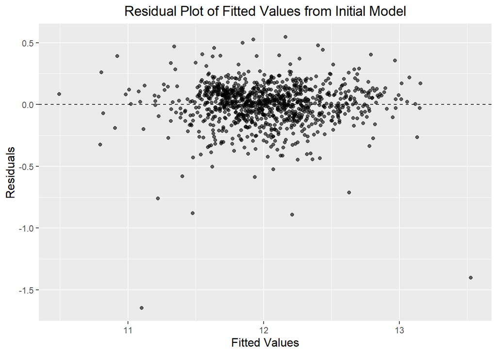

```r
lm_ames_train_init_aug <- broom::augment(lm_ames_train_init)

lm_ames_train_init_aug %>%
    ggplot(aes(x=.fitted, y=.resid)) +
    geom_point(alpha = 0.6) +
    geom_hline(yintercept = 0, linetype = 'dashed') +
    labs(title = "Residual Plot of Fitted Values from Initial Model", x= "Fitted Values", y= "Residuals") +
    theme(plot.title = element_text(size = 14, hjust = 0.5), axis.title.x =
          element_text(size = 12, hjust = 0.5), axis.title.y = element_text(size = 12, hjust = 0.5))
```

### 2.2.4 Section 2.4 Initial Model RMSE

You can calculate it directly based on the model output. Be specific about the units of your RMSE (depending on whether you transformed your response variable). The value you report will be more meaningful if it is in the original units (dollars).

After calculating the RMSE for our initial model, and transforming it back to dollars, the RMSE is $34,756.84.

```r
library(Metrics)
Predictions_init <- predict(lm_ames_train_init)
Residuals <- data.frame(na.omit(ames_train_init), Predictions_init)

Residuals <- Residuals %>%
  dplyr::select(Actual = logprice, Predictions_init) %>%
  mutate(Residual = Actual-Predictions_init, Actual_price = exp(Actual), Predicted_price = exp(Predictions_init))

rmse(Residuals$Actual_price, Residuals$Predicted_price)
```

```
## [1] 34756.84
```

### 2.2.5 Section 2.5 Overfitting

The process of building a model generally involves starting with an initial model (as you have done above), identifying its shortcomings, and adapting the model accordingly. This process may be repeated several times until the model fits the data reasonably well. However, the model may do well on training data but perform poorly out-of-sample (meaning, on a dataset other than the original training data) because the model is overly-tuned to specifically fit the training data. This is called “overfitting.” To determine whether overfitting is occurring on a model, compare the performance of a model on both in-sample and out-of-sample data sets. To look at performance of your initial model on out-of-sample data, you will use the data set `ames_test`.

```r
load("ames_test.Rdata")
```

Use your model from above to generate predictions for the housing prices in the test data set. Are the predictions significantly more accurate (compared to the actual sales prices) for the training data than the test data? Why or why not? Briefly explain how you determined that (what steps or processes did you use)?

After evaluating the RMSE of the test data set, we did not find evidence that our initial model overfits the training data set. In fact, the RMSE for the residuals of the test data set is less than the training data ($26,304.79 and $34,756.84 respectively). * * *

```r
ames_test_init <- ames_test %>%
  mutate(logprice = log(price), logarea = log(area)) %>%
  mutate(Features = ifelse(((is.na(Total.Bsmt.SF) | Total.Bsmt.SF == 0) & (is.na(Garage.Area) | Garage.Area ==0)), 'None', ifelse(((is.na(Total.Bsmt.SF) | Total.Bsmt.SF == 0) & !(is.na(Garage.Area) | Garage.Area == 0)), "Garage Only", ifelse(((is.na(Garage.Area) | Garage.Area == 0) & !(is.na(Total.Bsmt.SF) | Total.Bsmt.SF == 0)), "Basement Only", "Garage + Basement")))) %>%
  dplyr::select(logprice, Features, logarea, Overall.Qual, Overall.Cond, Total.Bsmt.SF, Garage.Area, Garage.Cars)

Predictions_test_init <- predict(lm_ames_train_init, ames_test_init)
Residuals_test <- data.frame(ames_test_init, Predictions_test_init)

Residuals_test <- Residuals_test %>%
  dplyr::select(Actual = logprice, Predictions_test_init) %>%
  mutate(Residual = Actual-Predictions_test_init, Actual_price = exp(Actual), Predicted_price = exp(Predictions_test_init))

rmse(Residuals_test$Actual_price, Residuals_test$Predicted_price)
```

```
## [1] 26304.79
```

**Note to the learner:** If in real-life practice this out-of-sample analysis shows evidence that the training data fits your model a lot better than the test data, it is probably a good idea to go back and revise the model (usually by simplifying the model) to reduce this overfitting. For simplicity, we do not ask you to do this on the assignment, however.

## 2.3 Part 3 Development of a Final Model

Now that you have developed an initial model to use as a baseline, create a final model with *at most* 20 variables to predict housing prices in Ames, IA, selecting from the full array of variables in the dataset and using any of the tools that we introduced in this specialization.

Carefully document the process that you used to come up with your final model, so that you can answer the questions below.

### 2.3.1 Section 3.1 Final Model

Provide the summary table for your model.

```r
ames_train_num <- ames_train %>%
  dplyr::select(area, Lot.Frontage, Lot.Area, Year.Built, Year.Remod.Add, Mas.Vnr.Area, BsmtFin.SF.1, BsmtFin.SF.2, Bsmt.Unf.SF, Total.Bsmt.SF, X1st.Flr.SF, X2nd.Flr.SF, Low.Qual.Fin.SF, Bsmt.Full.Bath, Bsmt.Half.Bath, Full.Bath, Half.Bath, Bedroom.AbvGr, Kitchen.AbvGr, TotRms.AbvGrd, Fireplaces, Garage.Yr.Blt, Garage.Cars, Garage.Area, Wood.Deck.SF, Open.Porch.SF, Enclosed.Porch, X3Ssn.Porch, Screen.Porch, Pool.Area, Misc.Val, Mo.Sold, Yr.Sold)

cor_num <- cor(ames_train_num)

ames_train <- ames_train %>%
  mutate(logprice = log(price), logarea = log(area))
#Year.Built and Garage.Yr.Blt (R = 0.87). Eliminate Garage.Yr.Blt
summary(lm(logprice ~ Year.Built, data = ames_train))$adj.r.squared
```

```
## [1] 0.3947132
```

```r
summary(lm(logprice ~ Garage.Yr.Blt, data = ames_train))$adj.r.squared
```

```
## [1] 0.3715174
```

```r
#area and TotRms.AbvGrd (R = 0.81). Eliminate TotRms.AbvGrd
summary(lm(logprice ~ area, data = ames_train))$adj.r.squared
```

```
## [1] 0.5104662
```

```r
summary(lm(logprice ~ TotRms.AbvGrd, data = ames_train))$adj.r.squared
```

```
## [1] 0.2694599
```

```r
#X1st.Flr.SF and Total.Bsmt.SF (R = 0.85). Eliminate X1st.Flr.SF
summary(lm(logprice ~ X1st.Flr.SF, data = ames_train))$adj.r.squared
```

```
## [1] 0.4250909
```

```r
summary(lm(logprice ~ Total.Bsmt.SF, data = ames_train))$adj.r.squared
```

```
## [1] 0.4454239
```

```r
#Garage.Cars and Garage.Area (R= 0.87). Elminiate Garage.Area
summary(lm(logprice ~ Garage.Cars, data = ames_train))$adj.r.squared
```

```
## [1] 0.4635242
```

```r
summary(lm(logprice ~ Garage.Area, data = ames_train))$adj.r.squared
```

```
## [1] 0.414411
```

```r
summary(ames_train)
```

```
##       PID                  area          price         MS.SubClass
##  Min.   : 526302030   Min.   : 334   Min.   : 12789   Min.   : 20.00
##  1st Qu.: 528477042   1st Qu.:1092   1st Qu.:129763   1st Qu.: 20.00
##  Median : 535425070   Median :1411   Median :159467   Median : 50.00
##  Mean   : 705924439   Mean   :1477   Mean   :181190   Mean   : 57.15
##  3rd Qu.: 907145180   3rd Qu.:1743   3rd Qu.:213000   3rd Qu.: 70.00
##  Max.   :1007100110   Max.   :4676   Max.   :615000   Max.   :190.00
##
##    MS.Zoning    Lot.Frontage       Lot.Area       Street     Alley
##  A (agr):  0   Min.   : 21.00   Min.   :  1470   Grvl:  3   Grvl: 33
##  C (all):  9   1st Qu.: 57.00   1st Qu.:  7314   Pave:997   Pave: 34
##  FV     : 56   Median : 69.00   Median :  9317              NA's:933
##  I (all):  1   Mean   : 69.21   Mean   : 10352
##  RH     :  7   3rd Qu.: 80.00   3rd Qu.: 11650
##  RL     :772   Max.   :313.00   Max.   :215245
##  RM     :155   NA's   :167
##  Lot.Shape Land.Contour  Utilities      Lot.Config  Land.Slope  Neighborhood
##  IR1:338   Bnk: 33      AllPub:1000   Corner :173   Gtl:962    NAmes  :155
##  IR2: 30   HLS: 38      NoSeWa:   0   CulDSac: 76   Mod: 33    CollgCr: 85
##  IR3:  3   Low: 20      NoSewr:   0   FR2    : 36   Sev:  5    Somerst: 74
##  Reg:629   Lvl:909                    FR3    :  5              OldTown: 71
##                                       Inside :710              Sawyer : 61
##                                                                Edwards: 60
##                                                                (Other):494
##   Condition.1   Condition.2   Bldg.Type    House.Style   Overall.Qual
##  Norm   :875   Norm   :988   1Fam  :823   1Story :521   Min.   : 1.000
##  Feedr  : 53   Feedr  :  6   2fmCon: 20   2Story :286   1st Qu.: 5.000
##  Artery : 23   Artery :  2   Duplex: 35   1.5Fin : 98   Median : 6.000
##  RRAn   : 14   PosN   :  2   Twnhs : 38   SLvl   : 41   Mean   : 6.095
##  PosN   : 11   PosA   :  1   TwnhsE: 84   SFoyer : 36   3rd Qu.: 7.000
##  RRAe   : 11   RRNn   :  1                2.5Unf : 10   Max.   :10.000
##  (Other): 13   (Other):  0                (Other):  8
##   Overall.Cond     Year.Built   Year.Remod.Add   Roof.Style    Roof.Matl
##  Min.   :1.000   Min.   :1872   Min.   :1950   Flat   :  9   CompShg:984
##  1st Qu.:5.000   1st Qu.:1955   1st Qu.:1966   Gable  :775   Tar&Grv: 11
##  Median :5.000   Median :1975   Median :1992   Gambrel:  8   WdShake:  2
##  Mean   :5.559   Mean   :1972   Mean   :1984   Hip    :204   WdShngl:  2
##  3rd Qu.:6.000   3rd Qu.:2001   3rd Qu.:2004   Mansard:  4   Metal  :  1
##  Max.   :9.000   Max.   :2010   Max.   :2010   Shed   :  0   ClyTile:  0
##                                                              (Other):  0
```

[output cut: 89 more lines]

```
##  Min.   : 1.000   Min.   :2006   WD     :863   Abnorml: 61    Min.   : 9.456
##  1st Qu.: 4.000   1st Qu.:2007   New    : 79   AdjLand:  2    1st Qu.:11.773
##  Median : 6.000   Median :2008   COD    : 27   Alloca :  4    Median :11.980
##  Mean   : 6.243   Mean   :2008   ConLD  :  7   Family : 17    Mean   :12.018
##  3rd Qu.: 8.000   3rd Qu.:2009   ConLw  :  6   Normal :834    3rd Qu.:12.269
##  Max.   :12.000   Max.   :2010   Con    :  5   Partial: 82    Max.   :13.329
##                                  (Other): 13
##     logarea
##  Min.   :5.811
##  1st Qu.:6.996
##  Median :7.252
##  Mean   :7.241
##  3rd Qu.:7.464
##  Max.   :8.450
##
```

```r
colSums(ames_train_num != 0, na.rm = TRUE)
```

```
##            area    Lot.Frontage        Lot.Area      Year.Built  Year.Remod.Add
##            1000             833            1000            1000            1000
##    Mas.Vnr.Area    BsmtFin.SF.1    BsmtFin.SF.2     Bsmt.Unf.SF   Total.Bsmt.SF
##             400             699             115             918             978
##     X1st.Flr.SF     X2nd.Flr.SF Low.Qual.Fin.SF  Bsmt.Full.Bath  Bsmt.Half.Bath
##            1000             398              12             431              59
##       Full.Bath       Half.Bath   Bedroom.AbvGr   Kitchen.AbvGr   TotRms.AbvGrd
##             997             371             998             999            1000
##      Fireplaces   Garage.Yr.Blt     Garage.Cars     Garage.Area    Wood.Deck.SF
##             509             952             953             953             483
##   Open.Porch.SF  Enclosed.Porch     X3Ssn.Porch    Screen.Porch       Pool.Area
##             562             166              14              79               3
##        Misc.Val         Mo.Sold         Yr.Sold
##              29            1000            1000
```

```r
#remove PID since it is merely a primary key and is not descriptive of any location
#eliminate Street, Utilities, Land.Slope, Condition.2, Roof.Matl, Heating, Central.Air, Electrical, Pool.QC, Misc.Feature, Alley, Land.Contour, Bsmt.Cond, Electrical, Garage.Qual, Garage.Cond, Functional, Bsmt.Half.Bath, Low.Qual.Fin.SF, X3Ssn.Porch, Screen.Porch, Pool.Area, Misc.Val, and Paved.Drive since > 90% of each variable's observations are a single category
# to satisfy parsimony, also eliminate BsmtFin.SF.1, BsmtFin.SF.2
ames_train_abbr <- ames_train %>%
  mutate(logprice = log(price), logarea = log(area)) %>%
  dplyr::select(-c('Garage.Yr.Blt', 'TotRms.AbvGrd', 'X1st.Flr.SF', 'Garage.Area', 'PID', 'Street', 'Utilities', 'Land.Slope', 'Land.Contour', 'Condition.2', 'Roof.Matl', 'Heating', 'Central.Air', 'Electrical', 'Pool.QC', 'Misc.Feature', 'Alley', 'Land.Contour', 'Bsmt.Cond', 'Electrical', 'Garage.Qual', 'Garage.Cond', 'Functional', 'Paved.Drive', 'Bsmt.Half.Bath', 'Low.Qual.Fin.SF', 'X3Ssn.Porch', 'Screen.Porch', 'Pool.Area', 'Misc.Val', 'BsmtFin.SF.1', 'BsmtFin.SF.2')) %>%
  mutate(Mas.Vnr.Area = ifelse(is.na(Mas.Vnr.Area), 0, Mas.Vnr.Area),
         Bsmt.Unf.SF = ifelse(is.na(Bsmt.Unf.SF), 0, Bsmt.Unf.SF),
         Bsmt.Full.Bath = ifelse(is.na(Bsmt.Full.Bath), 0, Bsmt.Full.Bath),
         Total.Bsmt.SF = ifelse(is.na(Total.Bsmt.SF), 0, Total.Bsmt.SF),
         Garage.Cars = ifelse(is.na(Garage.Cars), 0, Garage.Cars),
         Lot.Frontage = ifelse(is.na(Lot.Frontage), 0, Lot.Frontage)) %>%
  dplyr::select(-c(area, price))

#replacing NAs in data:
colSums(is.na(ames_train_abbr))
```

```
##    MS.SubClass      MS.Zoning   Lot.Frontage       Lot.Area      Lot.Shape
##              0              0              0              0              0
##     Lot.Config   Neighborhood    Condition.1      Bldg.Type    House.Style
##              0              0              0              0              0
##   Overall.Qual   Overall.Cond     Year.Built Year.Remod.Add     Roof.Style
##              0              0              0              0              0
##   Exterior.1st   Exterior.2nd   Mas.Vnr.Type   Mas.Vnr.Area     Exter.Qual
##              0              0              0              0              0
##     Exter.Cond     Foundation      Bsmt.Qual  Bsmt.Exposure BsmtFin.Type.1
##              0              0             21             21             21
## BsmtFin.Type.2    Bsmt.Unf.SF  Total.Bsmt.SF     Heating.QC    X2nd.Flr.SF
##             21              0              0              0              0
## Bsmt.Full.Bath      Full.Bath      Half.Bath  Bedroom.AbvGr  Kitchen.AbvGr
##              0              0              0              0              0
##   Kitchen.Qual     Fireplaces   Fireplace.Qu    Garage.Type  Garage.Finish
##              0              0            491             46             46
##    Garage.Cars   Wood.Deck.SF  Open.Porch.SF Enclosed.Porch          Fence
##              0              0              0              0            798
##        Mo.Sold        Yr.Sold      Sale.Type Sale.Condition       logprice
##              0              0              0              0              0
##        logarea
##              0
```

```r
ames_train_abbr[is.na(ames_train_abbr$Bsmt.Qual), 23] <- ''
ames_train_abbr[is.na(ames_train_abbr$Bsmt.Exposure), 24] <- ''
ames_train_abbr[is.na(ames_train_abbr$BsmtFin.Type.1), 25] <- ''
ames_train_abbr[is.na(ames_train_abbr$BsmtFin.Type.2), 26] <- ''
ames_train_abbr$Fireplace.Qu <- as.character(ames_train_abbr$Fireplace.Qu)
ames_train_abbr[is.na(ames_train_abbr$Fireplace.Qu), 38] <- 'No'
ames_train_abbr$Fireplace.Qu <- as.factor(ames_train_abbr$Fireplace.Qu)
ames_train_abbr$Garage.Type <- as.character(ames_train_abbr$Garage.Type)
ames_train_abbr[is.na(ames_train_abbr$Garage.Type), 39] <- 'No'
ames_train_abbr$Garage.Type <- as.factor(ames_train_abbr$Garage.Type)
ames_train_abbr$Garage.Finish <- as.character(ames_train_abbr$Garage.Finish)
ames_train_abbr[is.na(ames_train_abbr$Garage.Finish), 40] <- 'No'
ames_train_abbr$Garage.Finish <- as.factor(ames_train_abbr$Garage.Finish)
ames_train_abbr$Fence <- as.character(ames_train_abbr$Fence)
ames_train_abbr[is.na(ames_train_abbr$Fence), 45] <- 'No'
ames_train_abbr$Fence <- as.factor(ames_train_abbr$Fence)

tonum <- sapply(ames_train_abbr, is.factor)
ames_train_abbr[tonum] <- lapply(ames_train_abbr[tonum], function(x)as.numeric(x))
cor_abbr <- cor(ames_train_abbr)
#MS.SubClass and Bldg.Type (R = 0.76). Eliminate MS.SubClass
summary(lm(logprice ~ MS.SubClass, data = ames_train))$adj.r.squared
```

```
## [1] 0.003449073
```

```r
summary(lm(logprice ~ Bldg.Type, data = ames_train))$adj.r.squared
```

```
## [1] 0.02705692
```

```r
#Exterior.1st and Exterior.2nd (R = 0.87). Eliminate Exterior.2nd
summary(lm(logprice ~ Exterior.1st, data = ames_train))$adj.r.squared
```

```
## [1] 0.1882934
```

```r
summary(lm(logprice ~ Exterior.2nd, data = ames_train))$adj.r.squared
```

```
## [1] 0.1859636
```

```r
ames_train_abbr <- ames_train_abbr %>%
  dplyr::select(-c('MS.SubClass', 'Exterior.2nd'))

lm_abbr <- lm(logprice ~ ., data = ames_train_abbr)
score_step <- stepAIC(lm_abbr, k = log(48), trace = FALSE)
score_step
```

```
##
## Call:
## lm(formula = logprice ~ Lot.Area + Bldg.Type + Overall.Qual +
##     Overall.Cond + Year.Built + Exter.Cond + Bsmt.Exposure +
##     Bsmt.Unf.SF + Total.Bsmt.SF + Heating.QC + Bsmt.Full.Bath +
##     Bedroom.AbvGr + Kitchen.AbvGr + Kitchen.Qual + Fireplaces +
##     Fireplace.Qu + Garage.Cars + Open.Porch.SF + Sale.Condition +
##     logarea, data = ames_train_abbr)
##
## Coefficients:
##    (Intercept)        Lot.Area       Bldg.Type    Overall.Qual    Overall.Cond
##    1.276731715     0.000001927    -0.020769197     0.072519225     0.065026738
##     Year.Built      Exter.Cond   Bsmt.Exposure     Bsmt.Unf.SF   Total.Bsmt.SF
##    0.003250080     0.025985561    -0.007534906    -0.000065665     0.000180219
##     Heating.QC  Bsmt.Full.Bath   Bedroom.AbvGr   Kitchen.AbvGr    Kitchen.Qual
##   -0.013383964     0.047492673    -0.017219924    -0.054138091    -0.015696994
##     Fireplaces    Fireplace.Qu     Garage.Cars   Open.Porch.SF  Sale.Condition
##    0.031974397    -0.009595446     0.038034370    -0.000141961     0.026919099
##        logarea
##    0.456288235
```

```r
ames_train_BIC <- ames_train_abbr %>%
  dplyr::select(c('Lot.Area', 'Bldg.Type', 'Overall.Qual', 'Overall.Cond', 'Year.Built', 'Exter.Cond', 'Bsmt.Exposure', 'Bsmt.Unf.SF', 'Total.Bsmt.SF', 'Heating.QC', 'Bsmt.Full.Bath', 'Bedroom.AbvGr', 'Kitchen.AbvGr', 'Kitchen.Qual', 'Fireplaces', 'Fireplace.Qu', 'Garage.Cars', 'Open.Porch.SF', 'Sale.Condition', 'logarea', 'logprice'))

lm_BIC <- lm(logprice ~ ., data = ames_train_BIC)
#Through here
#BMA

bas <- bas.lm(logprice ~ ., data = ames_train_abbr, prior = "ZS-null")

summary(bas)
```

```
##                P(B != 0 | Y)      model 1   model 2      model 3      model 4
## Intercept         1.00000000    1.0000000    1.0000    1.0000000    1.0000000
## MS.Zoning         0.02380838    0.0000000    0.0000    0.0000000    0.0000000
## Lot.Frontage      0.02202746    0.0000000    0.0000    0.0000000    0.0000000
## Lot.Area          0.99498979    1.0000000    1.0000    1.0000000    1.0000000
## Lot.Shape         0.10692802    0.0000000    0.0000    0.0000000    0.0000000
## Lot.Config        0.06823008    0.0000000    0.0000    0.0000000    0.0000000
## Neighborhood      0.03942798    0.0000000    0.0000    0.0000000    0.0000000
## Condition.1       0.02311967    0.0000000    0.0000    0.0000000    0.0000000
## Bldg.Type         0.99988242    1.0000000    1.0000    1.0000000    1.0000000
## House.Style       0.07170586    0.0000000    0.0000    0.0000000    0.0000000
## Overall.Qual      1.00000000    1.0000000    1.0000    1.0000000    1.0000000
## Overall.Cond      1.00000000    1.0000000    1.0000    1.0000000    1.0000000
## Year.Built        1.00000000    1.0000000    1.0000    1.0000000    1.0000000
## Year.Remod.Add    0.06719720    0.0000000    0.0000    0.0000000    0.0000000
## Roof.Style        0.02120136    0.0000000    0.0000    0.0000000    0.0000000
## Exterior.1st      0.09464879    0.0000000    0.0000    0.0000000    0.0000000
## Mas.Vnr.Type      0.02895309    0.0000000    0.0000    0.0000000    0.0000000
## Mas.Vnr.Area      0.02170354    0.0000000    0.0000    0.0000000    0.0000000
## Exter.Qual        0.20416594    0.0000000    0.0000    0.0000000    0.0000000
## Exter.Cond        0.99814216    1.0000000    1.0000    1.0000000    1.0000000
## Foundation        0.02398359    0.0000000    0.0000    0.0000000    0.0000000
## Bsmt.Qual         0.03347570    0.0000000    0.0000    0.0000000    0.0000000
## Bsmt.Exposure     0.11228388    0.0000000    0.0000    0.0000000    0.0000000
## BsmtFin.Type.1    0.03812707    0.0000000    0.0000    0.0000000    0.0000000
## BsmtFin.Type.2    0.02903431    0.0000000    0.0000    0.0000000    0.0000000
## Bsmt.Unf.SF       0.99967641    1.0000000    1.0000    1.0000000    1.0000000
## Total.Bsmt.SF     1.00000000    1.0000000    1.0000    1.0000000    1.0000000
## Heating.QC        0.99853664    1.0000000    1.0000    1.0000000    1.0000000
## X2nd.Flr.SF       0.12581795    0.0000000    0.0000    0.0000000    0.0000000
## Bsmt.Full.Bath    0.98170737    1.0000000    1.0000    1.0000000    1.0000000
## Full.Bath         0.04416982    0.0000000    0.0000    0.0000000    0.0000000
## Half.Bath         0.05804812    0.0000000    0.0000    0.0000000    0.0000000
## Bedroom.AbvGr     0.35164901    0.0000000    1.0000    0.0000000    1.0000000
## Kitchen.AbvGr     0.23049298    0.0000000    0.0000    0.0000000    0.0000000
## Kitchen.Qual      0.92237449    1.0000000    1.0000    1.0000000    1.0000000
## Fireplaces        0.99034716    1.0000000    1.0000    1.0000000    1.0000000
## Fireplace.Qu      0.31969662    0.0000000    0.0000    1.0000000    1.0000000
## Garage.Type       0.04942558    0.0000000    0.0000    0.0000000    0.0000000
## Garage.Finish     0.03342817    0.0000000    0.0000    0.0000000    0.0000000
```

[output cut: 55 more lines]

```
## Garage.Cars       1.0000000
## Wood.Deck.SF      0.0000000
## Open.Porch.SF     0.0000000
## Enclosed.Porch    0.0000000
## Fence             0.0000000
## Mo.Sold           0.0000000
## Yr.Sold           0.0000000
## Sale.Type         0.0000000
## Sale.Condition    1.0000000
## logarea           1.0000000
## BF                0.3392418
## PostProbs         0.0110000
## R2                0.8941000
## dim              17.0000000
## logmarg        1061.4307157
```

```r
MPM <- predict(bas, estimator = "MPM")
HPM <- predict(bas, estimator = "HPM")
BPM <- predict(bas, estimator = "BPM")

variable.names(MPM)
```

```
##  [1] "Intercept"      "Lot.Area"       "Bldg.Type"      "Overall.Qual"
##  [5] "Overall.Cond"   "Year.Built"     "Exter.Cond"     "Bsmt.Unf.SF"
##  [9] "Total.Bsmt.SF"  "Heating.QC"     "Bsmt.Full.Bath" "Kitchen.Qual"
## [13] "Fireplaces"     "Garage.Cars"    "Sale.Condition" "logarea"
```

```r
variable.names(HPM)
```

```
##  [1] "Intercept"      "Lot.Area"       "Bldg.Type"      "Overall.Qual"
##  [5] "Overall.Cond"   "Year.Built"     "Exter.Cond"     "Bsmt.Unf.SF"
##  [9] "Total.Bsmt.SF"  "Heating.QC"     "Bsmt.Full.Bath" "Kitchen.Qual"
## [13] "Fireplaces"     "Garage.Cars"    "Sale.Condition" "logarea"
```

```r
variable.names(BPM)
```

```
##  [1] "Intercept"      "Lot.Area"       "Bldg.Type"      "Overall.Qual"
##  [5] "Overall.Cond"   "Year.Built"     "Exter.Cond"     "Bsmt.Unf.SF"
##  [9] "Total.Bsmt.SF"  "Heating.QC"     "Bsmt.Full.Bath" "Kitchen.Qual"
## [13] "Fireplaces"     "Garage.Cars"    "Sale.Condition" "logarea"
```

```r
lm_bas <- lm(logprice ~ Lot.Area + Bldg.Type + Overall.Qual + Overall.Cond + Year.Built + Exter.Cond + Bsmt.Unf.SF + Total.Bsmt.SF + Heating.QC + Bsmt.Full.Bath +
               Kitchen.Qual + Fireplaces + Garage.Cars + Sale.Condition + logarea, data = ames_train_abbr)

summary(lm_bas)$adj.r.squared
```

```
## [1] 0.891914
```

```r
sum(summary(lm_bas)$residuals^2)
```

```
## [1] 18.81495
```

```r
summary(lm_BIC)$adj.r.squared
```

```
## [1] 0.8940775
```

```r
sum(summary(lm_BIC)$residuals^2)
```

```
## [1] 18.34465
```

```r
lm_final <- lm_BIC
summary(lm_final)
```

```
##
## Call:
## lm(formula = logprice ~ ., data = ames_train_BIC)
##
## Residuals:
##      Min       1Q   Median       3Q      Max
## -1.38442 -0.06722  0.00114  0.07416  0.52475
##
## Coefficients:
##                     Estimate    Std. Error t value             Pr(>|t|)
## (Intercept)     1.2767317149  0.5241942952   2.436             0.015044 *
## Lot.Area        0.0000019272  0.0000004864   3.962        0.00007975442 ***
## Bldg.Type      -0.0207691971  0.0040637419  -5.111        0.00000038555 ***
## Overall.Qual    0.0725192248  0.0057539336  12.603 < 0.0000000000000002 ***
## Overall.Cond    0.0650267381  0.0045268676  14.365 < 0.0000000000000002 ***
## Year.Built      0.0032500801  0.0002359038  13.777 < 0.0000000000000002 ***
## Exter.Cond      0.0259855606  0.0059114887   4.396        0.00001224405 ***
## Bsmt.Exposure  -0.0075349057  0.0037893271  -1.988             0.047039 *
## Bsmt.Unf.SF    -0.0000656650  0.0000146776  -4.474        0.00000858455 ***
## Total.Bsmt.SF   0.0001802195  0.0000163826  11.001 < 0.0000000000000002 ***
## Heating.QC     -0.0133839641  0.0029880347  -4.479        0.00000837552 ***
## Bsmt.Full.Bath  0.0474926735  0.0112666831   4.215        0.00002725002 ***
## Bedroom.AbvGr  -0.0172199242  0.0076335483  -2.256             0.024302 *
## Kitchen.AbvGr  -0.0541380907  0.0254684941  -2.126             0.033779 *
## Kitchen.Qual   -0.0156969937  0.0047077371  -3.334             0.000887 ***
## Fireplaces      0.0319743971  0.0082699291   3.866             0.000118 ***
## Fireplace.Qu   -0.0095954456  0.0039680203  -2.418             0.015779 *
## Garage.Cars     0.0380343696  0.0081691624   4.656        0.00000367083 ***
## Open.Porch.SF  -0.0001419606  0.0000676622  -2.098             0.036154 *
## Sale.Condition  0.0269190994  0.0043671129   6.164        0.00000000104 ***
## logarea         0.4562882352  0.0262653957  17.372 < 0.0000000000000002 ***
## ---
## Signif. codes:  0 '***' 0.001 '**' 0.01 '*' 0.05 '.' 0.1 ' ' 1
##
## Residual standard error: 0.1369 on 979 degrees of freedom
## Multiple R-squared:  0.8962, Adjusted R-squared:  0.8941
## F-statistic: 422.6 on 20 and 979 DF,  p-value: < 0.00000000000000022
```

### 2.3.2 Section 3.2 Transformation

Did you decide to transform any variables? Why or why not? Explain in a few sentences.

Yes, I did transform a couple of variables because, in our EDA, we found that using the natural log of price for prediction would be more effective because of the skewed distribution of price. Also, the same logic was applied to using the natural log of `area` instead of just `area`. Otherwise, I didn’t transform any other variables before choosing a final model.

### 2.3.3 Section 3.3 Variable Interaction

Did you decide to include any variable interactions? Why or why not? Explain in a few sentences.

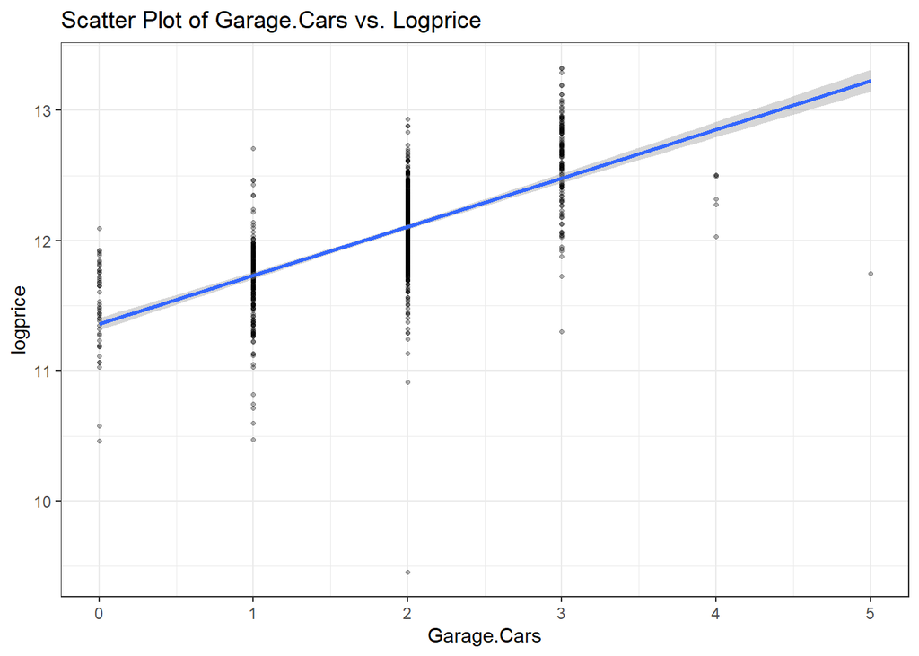

```r
#Showing scatter plot and regression line for Garage.Cars vs. logprice
ggplot(ames_train_abbr, aes(x=Garage.Cars, y=logprice)) + theme_bw() + geom_point(alpha = 0.3, size = 0.9) + geom_smooth(method = 'lm') + ggtitle("Scatter Plot of Garage.Cars vs. Logprice")
```

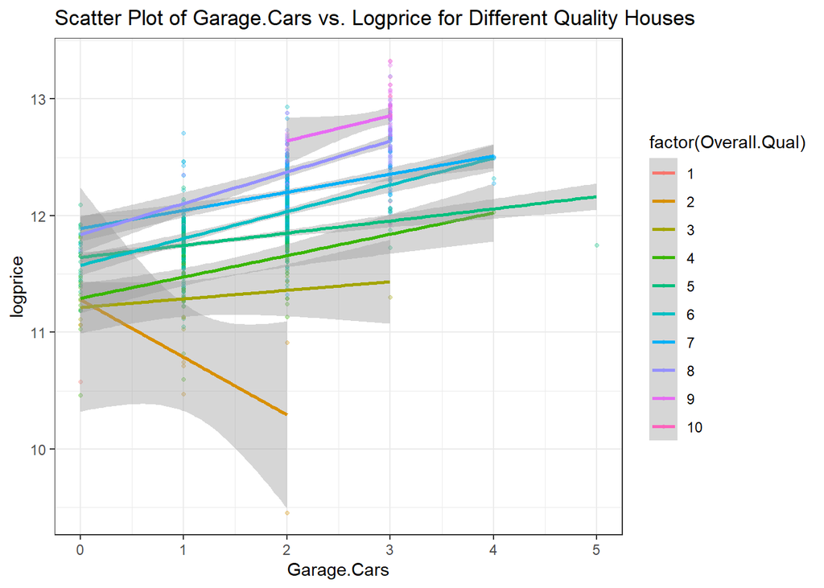

```r
#showing scatter plot and regression line for Garage.Cars vs. logprice broken up by Overall.Qual
ggplot(ames_train_abbr, aes(x=Garage.Cars, y=logprice, color = factor(Overall.Qual))) + theme_bw() + geom_point(alpha = 0.3, size = 0.9) + geom_smooth(method = 'lm') + ggtitle("Scatter Plot of Garage.Cars vs. Logprice for Different Quality Houses")
```

### 2.3.4 Section 3.4 Variable Selection

What method did you use to select the variables you included? Why did you select the method you used? Explain in a few sentences.

I used a few different methods to select the variables I included. Before utilizing a specific method, I wanted to eliminate any variables that would be either redundant or uninformative. To eliminate redundancy, I utilized a correlation plot to identify the variables that are highly-correlated and eliminate the one that was the least-predictive of logprice. Then, I eliminated `PID` since it is merely a primary key for each house, and has no predictive value. Then, to eliminate uninformative variables, I eliminated variables that lack sufficient data points (i.e. `Pool.QC` that has 997 NAs out of 1000 possible values). Additionally, I eliminated categorical variables that only have 1 value for all rows (i.e. `Utilities`).

```r
#NOTE: the variables used in the BPM, HPM, and MPM are all identical.  The lm_bas MLR model captures all 3.
variable.names(MPM)
```

```
##  [1] "Intercept"      "Lot.Area"       "Bldg.Type"      "Overall.Qual"
##  [5] "Overall.Cond"   "Year.Built"     "Exter.Cond"     "Bsmt.Unf.SF"
##  [9] "Total.Bsmt.SF"  "Heating.QC"     "Bsmt.Full.Bath" "Kitchen.Qual"
## [13] "Fireplaces"     "Garage.Cars"    "Sale.Condition" "logarea"
```

```r
variable.names(HPM)
```

```
##  [1] "Intercept"      "Lot.Area"       "Bldg.Type"      "Overall.Qual"
##  [5] "Overall.Cond"   "Year.Built"     "Exter.Cond"     "Bsmt.Unf.SF"
##  [9] "Total.Bsmt.SF"  "Heating.QC"     "Bsmt.Full.Bath" "Kitchen.Qual"
## [13] "Fireplaces"     "Garage.Cars"    "Sale.Condition" "logarea"
```

```r
variable.names(BPM)
```

```
##  [1] "Intercept"      "Lot.Area"       "Bldg.Type"      "Overall.Qual"
##  [5] "Overall.Cond"   "Year.Built"     "Exter.Cond"     "Bsmt.Unf.SF"
##  [9] "Total.Bsmt.SF"  "Heating.QC"     "Bsmt.Full.Bath" "Kitchen.Qual"
## [13] "Fireplaces"     "Garage.Cars"    "Sale.Condition" "logarea"
```

```r
summary(lm_bas)$adj.r.squared
```

```
## [1] 0.891914
```

```r
sum(summary(lm_bas)$residuals^2)
```

```
## [1] 18.81495
```

```r
summary(lm_BIC)$adj.r.squared
```

```
## [1] 0.8940775
```

```r
sum(summary(lm_BIC)$residuals^2)
```

```
## [1] 18.34465
```

### 2.3.5 Section 3.5 Model Testing

How did testing the model on out-of-sample data affect whether or how you changed your model? Explain in a few sentences.

When testing our final model on the test set, it performed better than on the training set. The RMSE for our final model on each set was $20,266.25 and $28,520.07 respectively. Because our model performs better on the test set, there is not a concern with overfitting, so we will move forward with this model.

```r
Predictions_final <- predict(lm_final)
Residuals_train <- data.frame(ames_train, Predictions_final)

Residuals_train <- Residuals_train %>%
  dplyr::select(Actual = logprice, Predictions_final) %>%
  mutate(Residual = Actual-Predictions_final, Actual_price = exp(Actual), Predicted_price = exp(Predictions_final)) %>%
  na.omit()


ames_test_final <- ames_test %>%
   dplyr::select(-c('Garage.Yr.Blt', 'TotRms.AbvGrd', 'X1st.Flr.SF', 'Garage.Area', 'PID', 'Condition.2', 'Roof.Matl', 'Roof.Style', 'Heating', 'Central.Air', 'Electrical', 'Functional', 'Garage.Qual', 'Garage.Cond', 'Paved.Drive', 'Pool.QC', 'Misc.Feature', 'Alley', 'Utilities')) %>%
  mutate(logprice = log(price), logarea = log(area)) %>%
  dplyr::select(-c(area, price))
tonum_test <- sapply(ames_test_final, is.factor)
ames_test_final[tonum_test] <- lapply(ames_test_final[tonum_test], function(x)as.numeric(x))

ames_test_final[is.na(ames_test_final$Bsmt.Qual), 25] <- 1
ames_test_final[is.na(ames_test_final$Bsmt.Exposure), 27] <- 1
ames_test_final[is.na(ames_test_final$BsmtFin.Type.1), 28] <- 1
ames_test_final[is.na(ames_test_final$BsmtFin.Type.2), 30] <- 1
ames_test_final$Fireplace.Qu <- as.character(ames_test_final$Fireplace.Qu)
ames_test_final[is.na(ames_test_final$Fireplace.Qu), 45] <- 'No'
ames_test_final$Fireplace.Qu <- as.numeric(as.factor(ames_test_final$Fireplace.Qu))
ames_test_final$Garage.Type <- as.character(ames_test_final$Garage.Type)
ames_test_final[is.na(ames_test_final$Garage.Type), 46] <- 'No'
ames_test_final$Garage.Type <- as.factor(ames_test_final$Garage.Type)
ames_test_final$Garage.Finish <- as.character(ames_test_final$Garage.Finish)
ames_test_final[is.na(ames_test_final$Garage.Finish), 47] <- 'No'
ames_test_final$Garage.Finish <- as.factor(ames_test_final$Garage.Finish)
ames_test_final$Fence <- as.character(ames_test_final$Fence)
ames_test_final[is.na(ames_test_final$Fence), 55] <- 'No'
ames_test_final$Fence <- as.factor(ames_test_final$Fence)

Predictions_test_final <- predict(lm_final, ames_test_final)
Residuals_test_final <- data.frame(ames_test_final, Predictions_test_final)

Residuals_test_final <- Residuals_test_final %>%
  dplyr::select(Actual = logprice, Predictions_test_final) %>%
  mutate(Residual = Actual-Predictions_test_final, Actual_price = exp(Actual), Predicted_price = exp(Predictions_test_final)) %>%
  na.omit()

rmse(Residuals_train$Actual_price, Residuals_train$Predicted_price)
```

```
## [1] 28520.07
```

```r
rmse(Residuals_test_final$Actual_price, Residuals_test_final$Predicted_price)
```

```
## [1] 20266.25
```

## 2.4 Part 4 Final Model Assessment

### 2.4.1 Section 4.1 Final Model Residual

For your final model, create and briefly interpret an informative plot of the residuals.

The Normal Q-Q plot shows that the predicted values are very close to the actual values for those within the 0-2 quantiles; however, more extreme values differ more and more, especially for negative quantiles.

The distribution of residuals does show a roughly normal distribution around zero, except for the couple of large negative residuals.

Overall, examining the residuals shows a model with good fit, but that doesn’t fit a couple of the extreme values well.

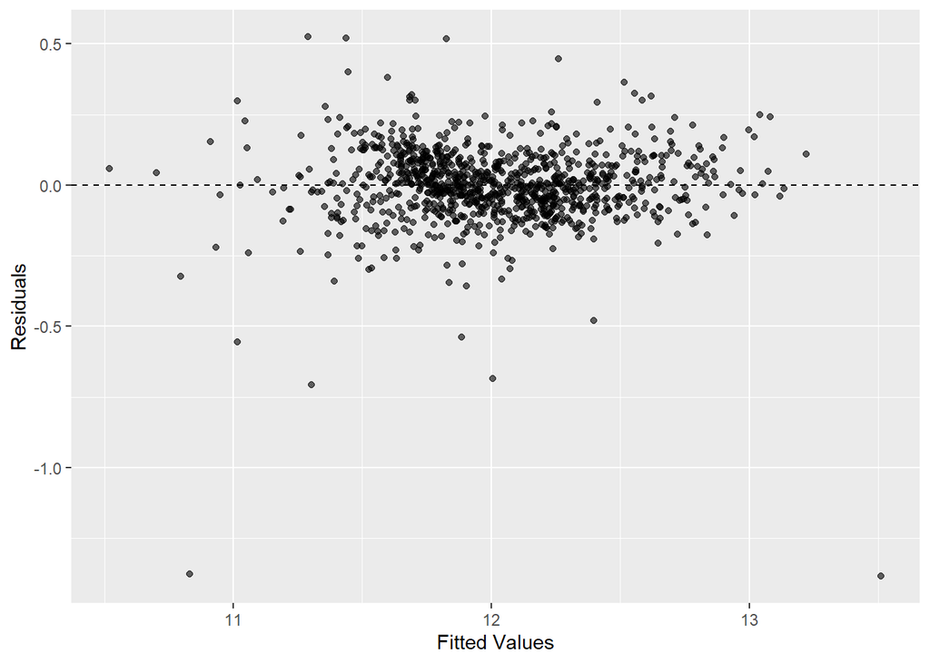

```r
lm_final_aug <- broom::augment(lm_final)
#Scatter Plot of Residuals
lm_final_aug %>%
    ggplot(aes(x=.fitted, y=.resid)) +
    geom_point(alpha = 0.6) +
    geom_hline(yintercept = 0, linetype = 'dashed') +
    labs(x= "Fitted Values", y= "Residuals")
```

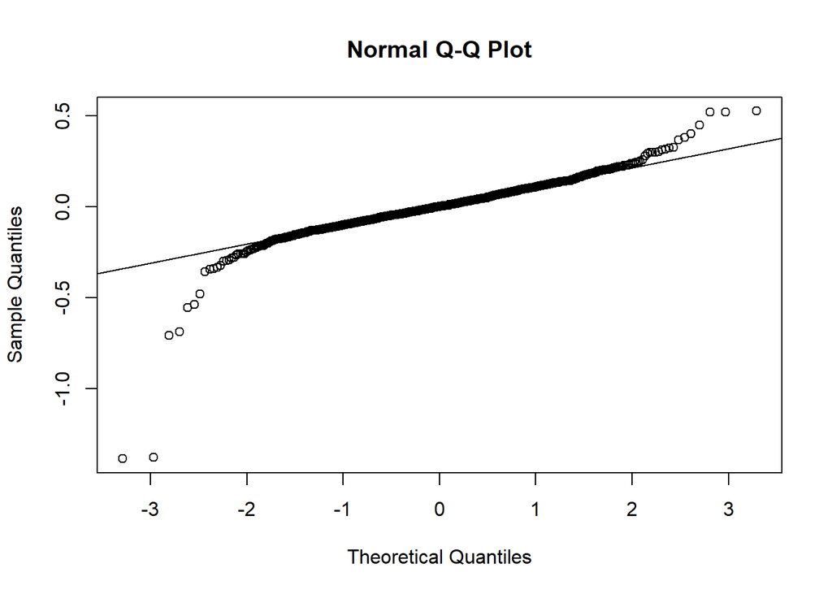

```r
#Normal Q-Q Plot
qqnorm(lm_final$residuals)
qqline(lm_final$residuals)
```

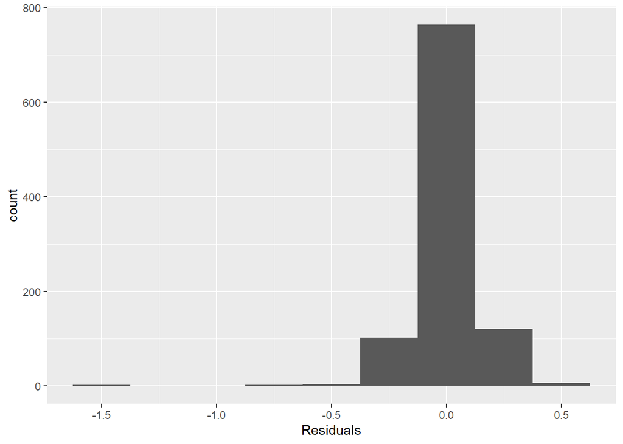

```r
#Distribution of Residuals
lm_final_aug %>%
    ggplot(aes(x=.resid)) +
    geom_histogram(binwidth = 0.25) +
    xlab('Residuals')
```

### Section 4.2 Final Model RMSE

For your final model, calculate and briefly comment on the RMSE.

```r
Predictions_final <- predict(lm_final, ames_train_abbr)
Residuals_train <- data.frame(ames_train_abbr, Predictions_final)

Residuals_train <- Residuals_train %>%
  dplyr::select(Actual = logprice, Predictions_final) %>%
  mutate(Residual = Actual-Predictions_final, Actual_price = exp(Actual), Predicted_price = exp(Predictions_final)) %>%
  na.omit()

rmse(Residuals_train$Actual_price, Residuals_train$Predicted_price)
```

```
## [1] 28520.07
```

### 2.4.2 Section 4.3 Final Model Evaluation

What are some strengths and weaknesses of your model?

Strengths: Our model does a very good job of predicting the price of a house when the explanatory variables are not outliers. With an R-squared of 0.8962, 89.62% of the variability in our data set can be explained by our model. Also, our model considers many different aspects of a house with the given data without creating redundancy. Lastly, the RMSE for our model when applied to the test data is lower than on the training data, which indicates that our model doesn’t overfit the training data set and should likely perform well on other samples of housing data with the same variables.

Weaknesses: Our model does not predict outlier variables very well, which is more typical of a model with fewer variables in it. Given the number of variables we have in our model, I would’ve expected it to be able to predict extreme values better than it does.

### 2.4.3 Section 4.4 Final Model Validation

Testing your final model on a separate, validation data set is a great way to determine how your model will perform in real-life practice.

You will use the “ames_validation” dataset to do some additional assessment of your final model. Discuss your findings, be sure to mention: * What is the RMSE of your final model when applied to the validation data?  
* How does this value compare to that of the training data and/or testing data? * What percentage of the 95% predictive confidence (or credible) intervals contain the true price of the house in the validation data set?  
* From this result, does your final model properly reflect uncertainty?

```r
load("ames_validation.Rdata")
```

Overall, 97.8% of the rows in our validation data had a `logprice` within the 95% confidence interval of our predictions, which is also encouraging.

Given the way our model performed on the validation data, our model reflects uncertainty about as well, if not better, than expected.

Some of the extreme values that have the highest residuals are PID 528360050, 902400110, and 532478020. The house with PID 528360050 was priced at $584,500 and our model predicted a price of $420,146.28. As you can see from the scatter plot below, the house, which is indicated by the red dot, is priced much higher than other houses with similar areas. In fact, it was the highest priced house in the validation data set. The house with PID 902400110 was priced at $475,000 and our model predicted a price of $343,685.73. This house was predicted to be lower than the actual price because, though the house is very large and in great overall condition (3608 sq ft and 9 respectively), the house was built in 1893. In this case, the fact that our model did not include the remodel year likely hurt the accuracy of our prediction (the house was remodeled in 1993).

On the other end, the house with PID 532478020 was priced at $275,000 and our model predicted a price of $382,514.42. For this house, the higher predicted price is likely due to the large area of the house; however, its exterior is also a low quality (3) which was not a variable included in our model.

```r
ames_validation <- ames_validation %>%
  mutate(logprice = log(price), logarea = log(area))

tonum_valid <- sapply(ames_validation, is.factor)
ames_validation[tonum_valid] <- lapply(ames_validation[tonum_valid], function(x)as.numeric(x))

ames_validation[is.na(ames_validation$Bsmt.Qual), 33] <- 1
ames_validation[is.na(ames_validation$Bsmt.Exposure), 35] <- 1
ames_validation[is.na(ames_validation$BsmtFin.Type.1), 36] <- 1
ames_validation[is.na(ames_validation$BsmtFin.Type.2), 38] <- 1
ames_validation$Fireplace.Qu <- as.character(ames_validation$Fireplace.Qu)
ames_validation[is.na(ames_validation$Fireplace.Qu), 59] <- 'No'
ames_validation$Fireplace.Qu <- as.numeric(as.factor(ames_validation$Fireplace.Qu))
ames_validation$Garage.Type <- as.character(ames_validation$Garage.Type)
ames_validation[is.na(ames_validation$Garage.Type), 60] <- 'No'
ames_validation$Garage.Type <- as.factor(ames_validation$Garage.Type)
ames_validation$Garage.Finish <- as.character(ames_validation$Garage.Finish)
ames_validation[is.na(ames_validation$Garage.Finish), 62] <- 'No'
ames_validation$Garage.Finish <- as.factor(ames_validation$Garage.Finish)
ames_validation$Fence <- as.character(ames_validation$Fence)
ames_validation[is.na(ames_validation$Fence), 75] <- 'No'
ames_validation$Fence <- as.factor(ames_validation$Fence)


Predictions_valid <- predict(lm_final, ames_validation)
Residuals_valid <- data.frame(ames_validation, Predictions_valid)

Residuals_valid <- Residuals_valid %>%
  dplyr::select(Actual = logprice, Predictions_valid) %>%
  mutate(Residual = Actual-Predictions_valid, Actual_price = exp(Actual), Predicted_price = exp(Predictions_valid)) %>%
  na.omit()

rmse(Residuals_valid$Actual_price, Residuals_valid$Predicted_price)
```

```
## [1] 20875.79
```

```r
predictions_final <- data.frame(Actual = ames_validation$logprice, predict(lm_final, ames_validation, interval = 'predict'))
predictions_final <- predictions_final %>%
  filter(!is.na(fit)) %>%
  mutate(In_Interval = ifelse(Actual >= lwr & Actual <= upr, 1, 0))

predictions_final %>%
  group_by(In_Interval) %>%
  summarise(Count = n(), Pct_of_Total = n()/763)
```

```
## # A tibble: 2 x 3
##   In_Interval Count Pct_of_Total
##         <dbl> <int>        <dbl>
## 1           0    16       0.0210
## 2           1   746       0.978
```

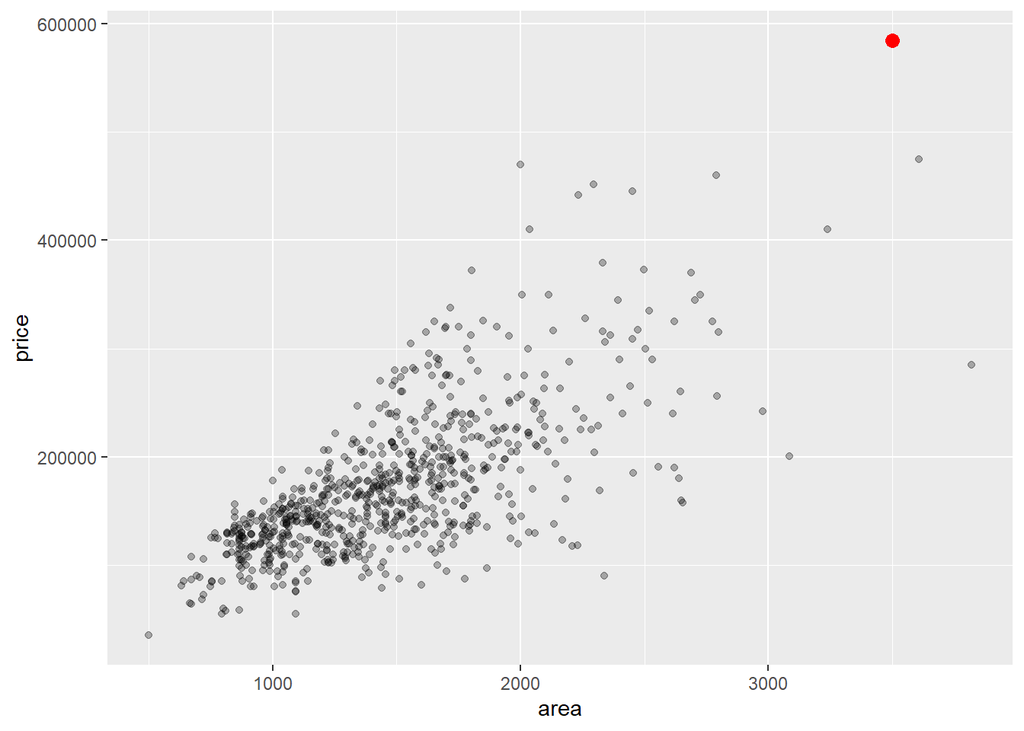

```r
predictions_final_dollars <- predictions_final %>%
  mutate(Actual = exp(Actual), fit = exp(fit), lwr = exp(lwr), upr = exp(upr))

#Showing validation data with largest residuals
predictions_final_dollars <- predictions_final_dollars %>%
  mutate(Resid = Actual - fit)
highlight_df <- ames_validation %>%
  filter(PID == 528360050)
ames_validation %>%
  ggplot(aes(x=area, y = price)) + geom_point(alpha = 0.3) + geom_point(data = highlight_df, aes(x=area, y=price), color = 'red', size = 3)
```

## 2.5 Part 5 Conclusion

Provide a brief summary of your results, and a brief discussion of what you have learned about the data and your model.

Though our final model wasn’t perfect as far as predicting housing prices, it performed better when being applied to data sets other than the one it was trained on, which is a positive indication of its effectiveness. Ultimately, I believe our final model performed as well as is possible with the tools we explored in this course. I think that being able to utilize variable interaction, as well as other feature engineering techniques that are outside the scope of this course could result in a better performing model. However, given the scope of this course, our model still performed very well when evaluating its effectiveness on the test and validation data sets.